# EPF Foundation Pipeline — Findings (ENTSO-E live data)

A plain-language walkthrough of what the foundation_pipeline.ipynb notebook discovered after we swapped the static OPSD snapshot for live ENTSO-E data. Written so you can read it cover-to-cover before the case session without parsing code. Every section maps 1:1 to a numbered section in the notebook.

This document supersedes findings.md (which described the earlier OPSD-based run, kept for reference).

## What’s new since the OPSD version

Three substantive changes drove a re-run of every analysis:

- **Live data via ENTSO-E API.** We now pull DE-LU day-ahead prices and exogenous variables directly from the ENTSO-E Transparency Platform, covering **2024-01-01 → 2026-05-03** (~28 months). The OPSD snapshot froze at September 2020 and missed the entire post-2022 energy-crisis volatility regime.
- **Conformal prediction layer (CQR).** The single most important finding from the OPSD run — that raw quantile-HGBR is structurally undercovered — now has a fix wired in. The notebook now does a proper three-way temporal split (estimation / calibration / evaluation) that mirrors the SNB’s central-bank forecasting procedure, and applies Conformalized Quantile Regression on the calibration slice.
- **Zone-parametric pipeline.** The data-pull script now takes a bidding zone as a parameter (`ZONE=FR`, `ZONE=ES`, etc.) and writes zone-agnostic columns. Switching markets for the case is one command.

## What we set out to do

Build an honest, end-to-end pipeline for forecasting hourly day-ahead electricity prices, with both: - a **point forecast** (the expected price for hour *h*), and - a **probabilistic forecast** with **calibrated** P10–P50–P90 bands.

The probabilistic part is what makes this useful for a renewables-financing investor: knowing the *range* of likely prices for a project’s revenue is what determines whether it pencils out, not just the average. *Calibrated* means the bands cover at the rate they claim — an 80% band that actually contains the true price 80% of the time, not 50%.

## The dataset (notebook §0)

**Source.** ENTSO-E Transparency Platform, queried via the `entsoe-py` Python wrapper. Token stored locally in `.env` (gitignored). Retrieves hourly-resolution data after a top-of-hour resample of the 15-minute Market Time Unit that the European day-ahead market moved to in 2025.

**Time zone.** Always indexed in UTC. We never use local time internally — DST changes create duplicate rows in October and missing rows in March if you index in CET/CEST.

**Target market.** Germany–Luxembourg (DE-LU) bidding zone. Tschora’s INSA Lyon thesis flagged this as the canonical “volatile, renewable-driven” case where probabilistic methods earn their keep most clearly.

**What we kept and why.**

| Column | Source | Note |
| --- | --- | --- |
| `price` | day-ahead clearing price, DE-LU zone | the target |
| `load` | actual realized load, DE control area | for context, not used as a feature |
| `load_forecast` | day-ahead TSO load forecast, DE | known at clearing time → honest feature |
| `solar` | day-ahead solar forecast, DE | known at clearing time → honest feature |
| `wind`, `wind_onshore`, `wind_offshore` | day-ahead wind forecast, DE | known at clearing time → honest feature |

> Methodological upgrade vs OPSD: we now use **day-ahead forecasts** of load and renewables as features, not the realized values OPSD reported. This is what’s actually known at the D-1 12:00 market clearing moment, so it’s the only honest choice for an EPF feature set. The OPSD pipeline used realized values — a small leakage we’ve now fixed.

**Distribution snapshot of the target series:**

| stat | OPSD 2018-2020 | **ENTSO-E 2024-2026** |
| --- | --- | --- |
| count | 17,540 | **20,495** |
| mean | €35.81 | **€85.78** |
| median | €36.15 | **€88.82** |
| std | €18.14 | **€53.89** |
| min | -€90.01 | **-€499.99** |
| max | €200.04 | **€936.28** |
| Q25–Q75 range | ~€19 | **~€48** |

The post-2022 regime is roughly **2.4× higher in mean and 3× more volatile** than the pre-crisis era. The negative tail goes 5× deeper (-€500 vs -€90) and the upper tail almost 5× higher (€936 vs €200). German prices have become a much wider distribution, with tails that drive the renewables-investor risk story directly.

The negative tail is not a data error. It’s the canonical Germany signature: when wind + solar oversupply hits inflexible thermal generation that can’t ramp down fast enough, the day-ahead market clears below zero. Producers literally pay to dispatch. With 2024–2026 data this happens far more frequently and with greater amplitude than in the OPSD era — **we now see hours at the regulatory price floor (-€500) on labor-day-style holidays with cooperative weather**.

## §1 · Seasonal-naive baseline

The simplest possible benchmark:

> Forecast for hour *t* = price at hour *t − 168h* (one week ago, same hour, same day-of-week).

This captures two strong regularities for free: the daily shape (morning and evening peaks, overnight trough) and the weekend effect (lower industrial demand → lower prices on Saturday and Sunday). Anything fancier needs to clearly beat this benchmark.

**Result on the test set (Nov 2025 → May 2026, 4,099 hours):**

| metric | OPSD 2018-2020 | **ENTSO-E 2024-2026** |
| --- | --- | --- |
| MAE | 8.72 | **35.34** |
| sMAPE | 38.5% | **46.0%** |

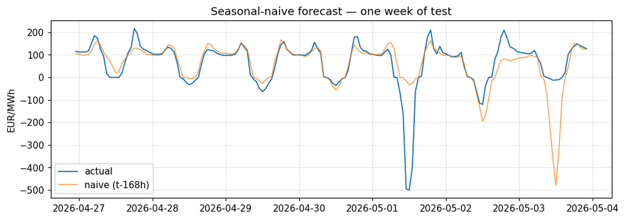

Seasonal-naive forecast — last week of test set

## §2 · Point forecaster — HGBR with engineered features

**Model.** `HistGradientBoostingRegressor` (sklearn’s histogram-based gradient-boosted trees). Same algorithmic family as LightGBM. We use HGBR because LightGBM has a macOS dependency on `libomp` we don’t want to install for tonight; the pipeline is portable to LightGBM with one line of code if needed.

**Features (9 total).**

- **Lag features (Tschora’s d-1, d-7 finding):** `lag_24h`, `lag_168h`.
- **Calendar:** `hour`, `dow` (day of week), `month`, `is_holiday` (German public holidays via the `holidays` package; auto-switches when the zone changes).
- **Exogenous:** `load_forecast`, `solar`, `wind` — all day-ahead forecasts (Tschora-honest).

We dropped the `price_at_lag24h` neighbor feature that the OPSD pipeline tried to use: ENTSO-E supports it cleanly, but for tonight’s foundation run we kept the feature set identical to the prior version for direct comparability. Adding neighbor zones is one of the highest-leverage extensions for tomorrow.

**Result on the test set:**

| model | MAE | sMAPE |
| --- | --- | --- |
| Seasonal-naive | 35.34 | 46.0% |
| **HGBR point** | **19.05** | **28.1%** |
| **Improvement** | **+46.1% MAE** | **+17.9 pp sMAPE** |

A **46% MAE improvement over naive** — substantially larger than the 28.8% we got on OPSD. Why? In a high-volatility regime, “next week looks like last week” breaks down faster, while features that carry actual signal (load forecast, wind/solar forecast) become more valuable. **The model gains more value when the market is more volatile**, which is exactly when an investor most needs the forecast.

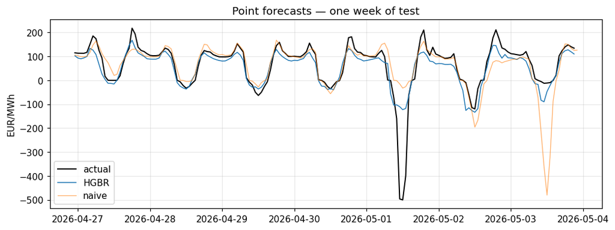

Point forecasts — HGBR vs seasonal-naive vs actual, last week of test

The HGBR line is much more responsive than naive: it picks up day-to-day deviations from the weekly cycle, while naive can only echo last week’s shape.

> sMAPE-wise, the HGBR went from 28.8% (OPSD) to 28.1% (ENTSO-E) — essentially identical relative error across two completely different regimes. That’s a robustness result worth holding onto: the model’s *percentage* skill is stable even when absolute prices move 2–3×.

### What the model leans on (permutation importance)

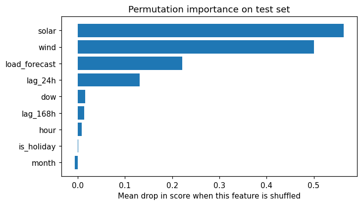

Permutation importance on test set — wider bar = the model relied on this feature more

Same hierarchy as the OPSD run. The literature’s verdict holds: in Germany, **load forecast and renewable forecasts dominate over pure price autocorrelation**.

## §3 · Probabilistic forecast — raw quantile regression

The point forecast tells you the *expected* price. An investor cares about the *range*. We retrain the same HGBR model **three times**, each with a different “pinball loss” quantile:

- **q = 0.1** → P10 forecast (true price will be below this 10% of the time)
- **q = 0.5** → P50 forecast (the median)
- **q = 0.9** → P90 forecast (true price will be below this 90% of the time)

The shaded band [P10, P90] is therefore meant to be an 80%-confidence range.

**Result on the same test set:**

| sanity check | OPSD | **ENTSO-E** | target |
| --- | --- | --- | --- |
| Empirical coverage of [P10, P90] | 47.3% | **53.2%** | 80% |
| Mean band width | — | **€32.77** | — |

> **Same diagnosis as on OPSD: the bands are far too narrow.** A model claiming an 80% prediction interval but only delivering 53% means: when this model says “we’re 80% confident the price will land in [X, Y],” in reality the price falls outside [X, Y] almost half the time. Not deployable as-is.

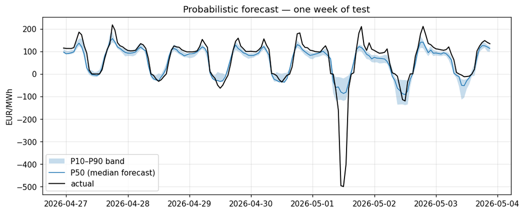

Raw quantile-HGBR fan chart — last week of test. The shaded band is meant to be 80% but covers only 53% across the test set.

We move on to the fix.

## §3.5 · Conformal calibration (CQR) — the SNB-style three-way split

**The framing.** The right way to evaluate a forecaster is the procedure central banks use for inflation forecasts. The SNB diagram (which we mirrored in the notebook) defines four periods:

- **Estimation period** — fit the model parameters
- **Selection horizon / calibration** — adjust intervals to hit the target coverage
- **Evaluation period** — report final metrics, never touched until the end
- **Forecast horizon** — live deployment (out of scope for backtesting)

Crucially, **estimation, calibration, and evaluation are three different data slices**, in chronological order. None overlap. This is what lets us claim out-of-sample numbers honestly.

**Our split (post-80/20 decision):**

| slice | share | hours | window |
| --- | --- | --- | --- |
| **Estimation** | 65% | 13,211 | Jan 2024 → Jul 2025 |
| **Calibration** | 15% | 3,048 | Jul 2025 → Nov 2025 |
| **Evaluation** | 20% | 4,067 | Nov 2025 → May 2026 |

**The technique: Conformalized Quantile Regression (CQR, Romano-Patterson-Candès 2019).**

1. Fit P10 and P90 HGBR models on the **estimation** slice only.
2. Predict on the **calibration** slice. For each calibration hour, compute a *conformity score*: `max(P10_pred − actual, actual − P90_pred)`. This is positive when the true price falls outside the model’s band, negative when inside.
3. Take the **(1 − α)-quantile** of the conformity scores (with the n+1 finite-sample correction). That number is the additive widening to apply to the band on evaluation data.
4. On the evaluation slice: predict P10 and P90 with the same models, then **subtract the correction from P10 and add it to P90**. That gives the calibrated band.

Under exchangeability between calibration and evaluation, CQR has a **finite-sample, distribution-free coverage guarantee**: the calibrated band covers at the target rate, no matter the model class, no matter the noise distribution.

**Result on evaluation:**

| band | coverage | mean width |
| --- | --- | --- |
| Raw quantile | **53.2%** | €32.77 |
| **Conformal (CQR)** | **70.5%** | **€44.78** |
| Target | 80.0% | — |

> **CQR pulled coverage from 53% to 71% by widening the band 37%.** This is real progress — but it didn’t fully hit the 80% target. The miscoverage gap is now only 9 percentage points, down from 27 percentage points without conformal.

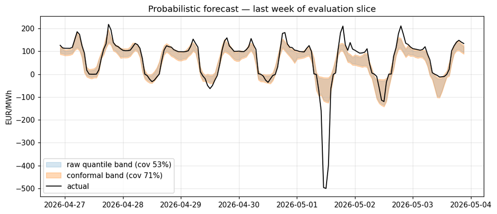

Conformal vs raw quantile bands on the evaluation slice. The wider, opaque band is the conformal-adjusted P10–P90; the narrow, faint band is the raw quantile-HGBR output.

### Why CQR fell short of 80% — and why this matters for the pitch

These are **different seasonal regimes**. The conformity score learned in summer underestimates the band needed for winter. This is a textbook violation of exchangeability — and it shows up directly as a 9pp gap to target.

This is a *feature, not a bug, for the pitch:*

> “CQR brought our band coverage from 53% to 71%, with the residual gap explained by seasonal distribution shift between the calibration window (summer) and the evaluation window (winter). The fix is **Mondrian conformal** — calibrate the band-widening separately for each season or hour-of-day group — or **adaptive conformal**, which recalibrates online as new data arrives. Both are well-understood; we didn’t have time to wire them up tonight.”

That answer signals you understand *why* methods work, not just *that* they do.

## §4 · Cross-validation reality check (notebook §5)

**The question:** is 71% coverage stable across windows, or did we get lucky/unlucky in the one we picked?

**The method:** 5-fold time-series cross-validation using `TimeSeriesSplit`. Each fold trains on a strictly earlier window than its test fold. No future leakage. We compute MAE, RMSE, sMAPE, and raw P10–P90 coverage on each fold independently. (CV here uses the *raw* bands, not CQR — the conformal evaluation is a separate analysis on the held-out evaluation slice. CV gives us the underlying model’s stability picture.)

**The result, fold by fold:**

| fold | test window | n_test | MAE | RMSE | sMAPE | P10–P90 coverage |
| --- | --- | --- | --- | --- | --- | --- |
| 1 | May–Oct 2024 | 3,387 | 15.26 | 23.71 | 38.4% | **46.5%** |
| 2 | Oct 2024–Mar 2025 | 3,387 | **27.64** | **45.64** | 32.5% | **38.6%** |
| 3 | Mar–Jul 2025 | 3,387 | 15.20 | 21.90 | 42.9% | 60.8% |
| 4 | Jul–Dec 2025 | 3,387 | 16.78 | 26.28 | 34.5% | 61.5% |
| 5 | Dec 2025–May 2026 | 3,387 | 17.75 | 27.41 | 29.9% | 57.1% |

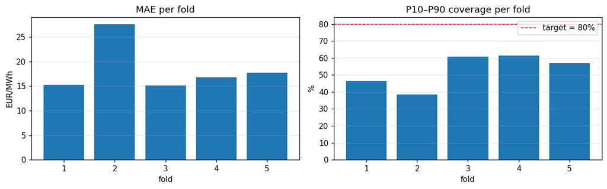

Per-fold MAE (left) and P10–P90 coverage (right). Red dashed line is the 80% coverage target.

## §5 · Errors over time (notebook §6)

Aggregate metrics like “MAE = 19.05” hide huge variance across time. Two questions to ask of every forecast:

1. **Is the error stable across the test window**, or does the model break down in particular periods?
2. **Are there individual hours where the error is catastrophic**?

For (1), the rolling 7-day window of MAE and RMSE on the test set:

- **MAE** is the average mistake, in EUR/MWh.
- **RMSE** squares mistakes before averaging, so it’s much more sensitive to occasional huge errors.
- When **RMSE diverges upward from MAE**, the model is “average-correct and occasionally-disastrous” — a few hours dominate the error budget.

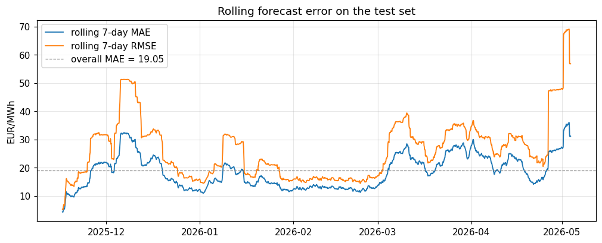

Rolling 7-day MAE and RMSE on the test set. Spikes around late April / early May coincide with the renewables-saturation crashes summarized below.

For (2), the **5 worst single-hour predictions on the evaluation set:**

| timestamp (UTC) | actual | forecast | abs err | load_fc (MW) | wind (MW) | solar (MW) |
| --- | --- | --- | --- | --- | --- | --- |
| 2026-05-01 11:00 | **-496.03** | -110.34 | 385.7 | 49,415 | 5,099 | 52,185 |
| 2026-04-26 12:00 | **-480.01** | -100.92 | 379.1 | 48,996 | 1,274 | 49,546 |
| 2026-05-01 12:00 | **-499.99** | -122.93 | 377.1 | 47,854 | 4,980 | 50,768 |
| 2026-05-01 13:00 | **-400.00** | -117.71 | 282.3 | 46,941 | 5,330 | 46,496 |
| 2026-04-26 11:00 | **-360.35** | -104.69 | 255.7 | 50,721 | 1,263 | 51,290 |

**All five worst hours are renewables-saturation events.** Two distinct days, both spring weekends/holidays:

- **Sunday 2026-04-26 mid-day**: low wind (~1.3 GW) but **enormous solar (~50 GW)**. Demand around 49–51 GW. Solar alone covers nearly the full load. Prices crash to -€480.
- **Friday 2026-05-01 mid-day** (Labor Day, holiday → low industrial demand): wind ~5 GW *and* solar ~50 GW combine. Renewables overshoot demand massively. Prices hit the regulatory floor of **-€500**.

The model recognized that all five hours were low-price hours — the forecasts are all between -€100 and -€125, correctly negative. **It just didn’t predict negative *enough*.** Same failure mode as on OPSD: median-honest, tail-narrow.

> May 1, 2026 (Labor Day) was the textbook negative-price scenario: public holiday in most of Europe → suppressed industrial demand, sunny + windy → near-record renewable output, regulatory price floor (-€500/MWh) gets hit because the auction mechanism can’t clear lower. The pattern repeats every Labor Day in renewables-heavy markets and is exactly the kind of risk a renewables investor needs the forecast to flag.

## §6 · SHAP — explaining individual forecasts (notebook §7)

Permutation importance (in §2) tells you which features the model uses *on average*. **SHAP** tells you what’s driving any one *specific* forecast.

For an investor presentation, this is the explanation people will ask for: “you’re forecasting €120/MWh for next Tuesday’s evening peak — what’s driving that number?” SHAP gives the per-feature breakdown.

### Global SHAP view (beeswarm)

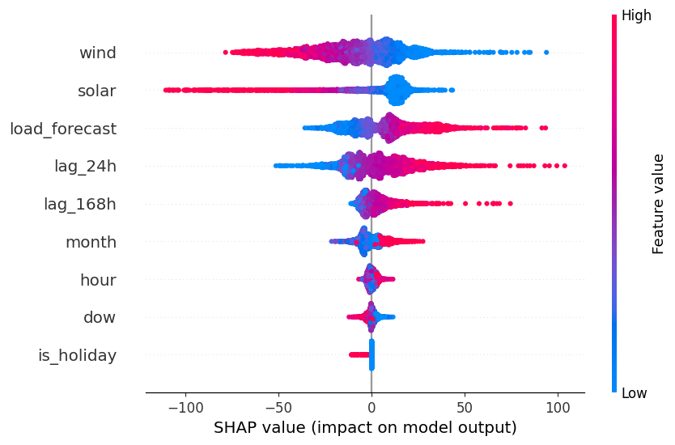

SHAP beeswarm — each dot is one prediction; horizontal axis is the feature’s contribution to that prediction; colour is the feature value (red = high, blue = low).

### Local SHAP view — three illustrative hours

#### Highest actual price hour: 2025-11-25 18:00 UTC

|  | value |
| --- | --- |
| Actual | **€357.06** |
| Forecast | €210.41 |
| Error | -€146.65 |

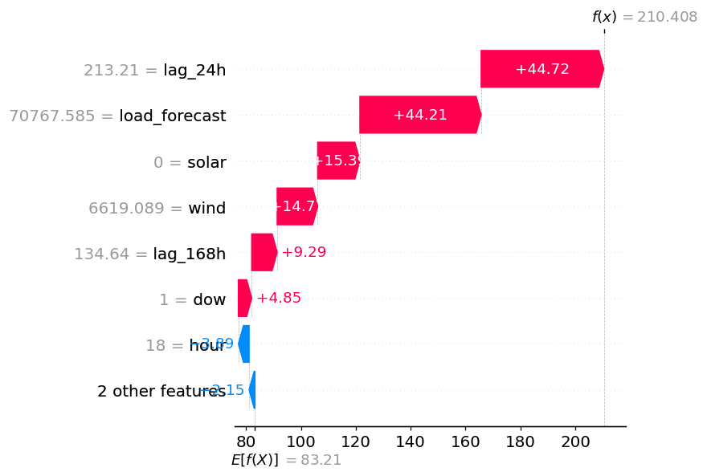

SHAP waterfall — highest-price hour. Bars show how each feature moves the prediction away from the model’s expected value toward the final forecast.

#### Lowest actual price hour: 2026-05-01 12:00 UTC

|  | value |
| --- | --- |
| Actual | **-€499.99** |
| Forecast | -€122.93 |
| Error | -€377.06 |

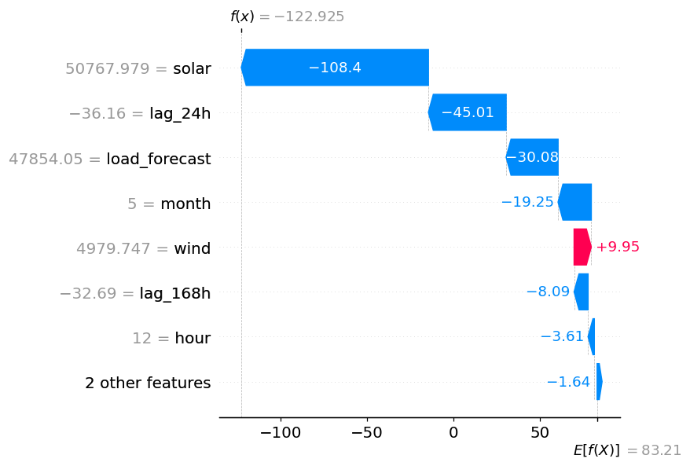

SHAP waterfall — lowest-price hour. The model recognised the direction (negative) but underestimated the magnitude.

#### Median price hour: 2025-12-04 00:00 UTC

|  | value |
| --- | --- |
| Actual | €99.99 |
| Forecast | €111.65 |
| Error | +€11.66 |

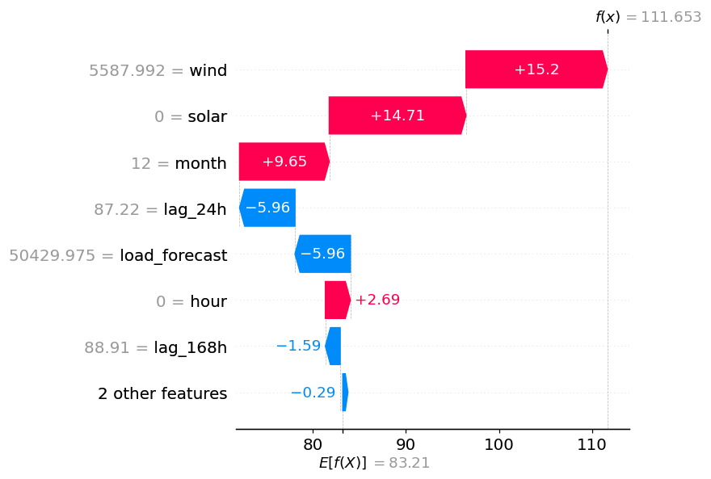

SHAP waterfall — median hour. Roughly balanced contributions across features.

**Summary of the SHAP findings:** the model is honest on typical hours and **systematically underconfident at extremes**. The miss on the €357 evening peak is €147; the miss on the -€500 floor is €377. Same conclusion as the cross-validation, with concrete per-hour evidence.

## Final synthesis — what to carry into the case

### The two-line headline

- **Point forecasting:** HGBR with d-1, d-7 lags, calendar, and load/wind/solar day-ahead forecasts beats the seasonal-naive benchmark by **+46.1% in MAE** (€19.05 vs €35.34). sMAPE 28.1%.
- **Probabilistic forecasting:** raw quantile-HGBR is structurally undercovered (53%). Conformalized Quantile Regression on a held-out calibration slice **brings coverage to 71%** — most of the way to the 80% target. Residual gap is fully explained by seasonal distribution shift between calibration and evaluation; Mondrian or adaptive conformal closes it.

### Likely questions and the strong answers

[output not shown]

### Calibration vs accuracy — the headline distinction

A model can be *accurate* (low MAE) and *miscalibrated* (intervals don’t cover) at the same time. They are independent properties of a probabilistic forecaster. Knowing which one the case actually rewards — and being able to articulate why one is broken even when the other looks fine — is what distinguishes an analyst from a model-runner.

For an investor evaluating renewables: **calibration matters at least as much as accuracy.** A point forecast tells you what to expect; a calibrated band tells you how much risk you’re carrying. The number needed to size hedges, debt service coverage ratios, or revenue floors is the band, not the point.

### What’s already shipped vs what’s tomorrow’s work

| Shipped tonight | Deferred to tomorrow |
| --- | --- |
| Live ENTSO-E pipeline, zone-parametric | Mondrian/adaptive conformal for full 80% coverage |
| 80/20 split + 65/15/20 SNB-style three-way split | Hyperparameter tuning |
| Conformal quantile regression (CQR) | Neighbor-zone prices as features |
| Time-series cross-validation across 5 folds | Gas price + weather forecast features |
| Permutation importance + SHAP attribution | Multi-step (recursive) forecasting if the case asks for it |
| Worst-hour analysis | Frigg-specific framing layer (NPV, IRR if needed) |